# Make Disposition

Author

Kendra Wyant

Published

July 5, 2024

## Notes

This script gets study start and end date, total months on study to create a disposition file for the Olivia’s PREP project using the qualitative burden data.

Decisions:

- Subid 1197 is excluded. They completed 11 burden surveys but had missing values in all fields for all surveys.
- Subid 1257 is excluded. They completed 5 burden surveys but had missing values in all fields for all surveys.
- Only 12 out of 245 participants completed a second burden survey. Only 2 people with a second survey completed the survey more than a month after their first survey and one of these people had NAs on comments for second survey. Decision to only keep first survey.
- 133 partcicipants have no quant data! Need to look at monthly cleaning script to see if problem introduced or these data are actually missing. We are only using qualitative data at the current moment. Since quant data only really adds a likert scale measure of dislike.

## Read in data

Read in burden data

```r
burden <- read_csv(here::here(path_prep, "burden_qual.csv"),
                         show_col_types = FALSE)
```

Read in daily survey - will use for study start and end date

Filter to only subids with at least one burden survey

```r
daily_survey <- read_csv(here::here(path_processed, "survey_daily.csv"),
                         show_col_types = FALSE) |>
  filter(subid %in% burden$subid & status == "complete") |>
  glimpse()
```

```
Rows: 818,565
Columns: 9
$ subid            <dbl> 1006, 1006, 1006, 1006, 1006, 1006, 1006, 1006, 1006,…
$ user_survey_guid <chr> "cb6d0540-00d5-497d-8189-f5e458afbac0", "cb6d0540-00d…
$ start_date       <dbl> 1619058849, 1619058849, 1619058849, 1619058849, 16190…
$ complete_date    <dbl> 1619058976, 1619058976, 1619058976, 1619058976, 16190…
$ status           <chr> "complete", "complete", "complete", "complete", "comp…
$ utc_offset       <chr> "{\"utc_offset_minutes\":-300}", "{\"utc_offset_minut…
$ variable_name    <chr> "drugs", "pain", "urge", "risk", "adherence", "hassle…
$ answer           <chr> "none of the above", "Mildly", "No urge", "No risky s…
$ answer_date      <dbl> 1619058894, 1619058939, 1619058939, 1619058939, 16190…
```

## Create disposition tibble

```r
daily_survey_start <- daily_survey |>
  group_by(subid) |>
  arrange(complete_date) |>
  slice(1)

daily_survey_end <- daily_survey |>
  group_by(subid) |>
  arrange(desc(complete_date)) |>
  slice(1)

disp <- daily_survey_start |>
  select(subid,
         start_dttm = complete_date) |>
  full_join(daily_survey_end |>
              select(subid,
                     end_dttm = complete_date), by = "subid") |>
  ungroup()
```

convert Unix time stamp to date

```r
disp <- disp |>
  mutate(start_dttm = as_datetime(start_dttm, tz = "America/Chicago"),
         end_dttm = as_datetime(end_dttm, tz = "America/Chicago"))

disp <- disp |>
  mutate(start_date = as_date(start_dttm),
         end_date = as_date(end_dttm)) |>
  select(-c(start_dttm, end_dttm))
```

calculate months on study

```r
disp <- disp |>
  rowwise() |>
  mutate(days_on_study = as.numeric(difftime(end_date, start_date, units = "days")),
         weeks_on_study = as.numeric(difftime(end_date, start_date, units = "weeks")),
         months_on_study = days_on_study/30)
```

## EDA

226 subids provided qualitative data.

Average time on study:

Days

```r
disp |>
  ungroup() |>
  summarise(mean_days = mean(days_on_study),
            min_days = min(days_on_study),
            max_days = max(days_on_study))
```

```
# A tibble: 1 × 3
  mean_days min_days max_days
      <dbl>    <dbl>    <dbl>
1      309.      122      416
```

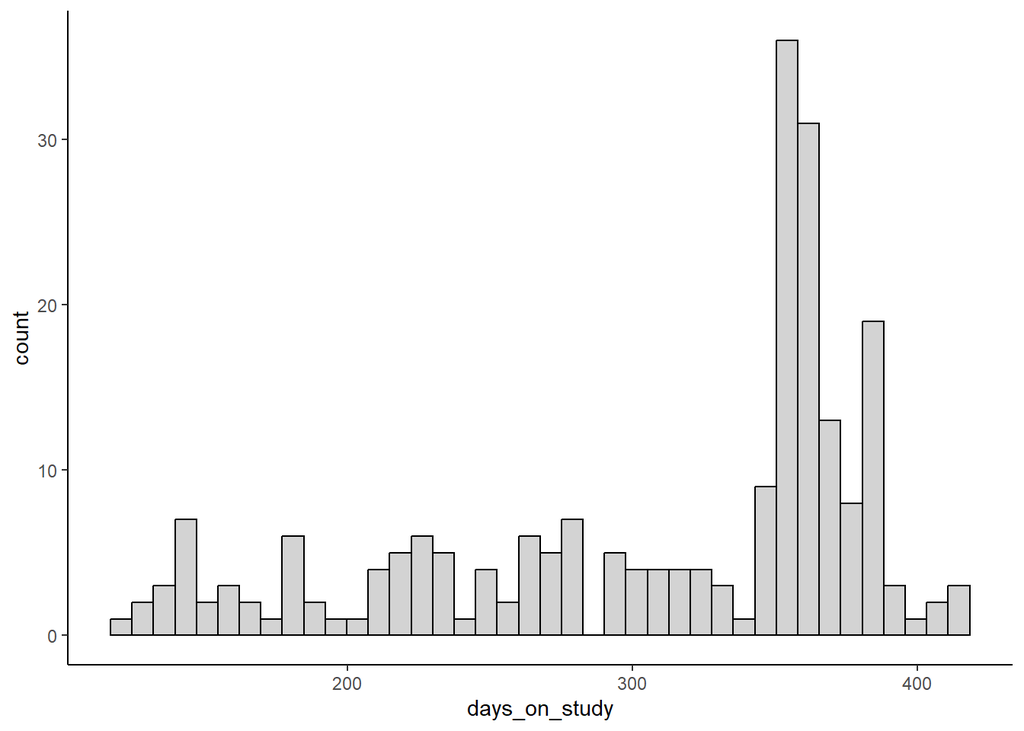

```r
disp |>
  ggplot(aes(x = days_on_study)) +
  geom_histogram(bins = 40, color = "black", fill = "light grey")
```

Burden survey taken between 2-5 months for all participants

```r
disp <- burden |>
  group_by(subid) |>
  slice(1) |>
  mutate(survey_date = as_datetime(complete_date, tz = "America/Chicago")) |>
  mutate(survey_date = as_date(survey_date)) |>
  select(subid, survey_date) |>
  right_join(disp, by = "subid")

disp |>
  mutate(survey_start_diff = difftime(survey_date, start_date, units = "days")) |>
  tabyl(survey_start_diff)
```

```
 survey_start_diff  n     percent
           66 days  1 0.004424779
           71 days  1 0.004424779
           92 days  1 0.004424779
           94 days  1 0.004424779
          117 days  1 0.004424779
          118 days  2 0.008849558
          120 days  2 0.008849558
          121 days 10 0.044247788
          122 days 81 0.358407080
          123 days 41 0.181415929
          124 days 19 0.084070796
          125 days  6 0.026548673
          126 days  7 0.030973451
          127 days  8 0.035398230
```

[output cut: 17 more lines]

Save out tibble

```r
disp |>
  write_csv(file.path(path_prep, "disposition.csv"))
```